# Analysis of Career Salaries by Major, College Type and Region

## Introduction

The Wall Street Journal collected data about a student's major, type of college attended and region of college and their career earnings at starting and mid career of their careers. They also went ahead and collected data about the salary collected at various percentiles during mid career.

In this project, I conducted an EDA to determine how each of the above mentioned factors contribute to a student's prospective career earning. College applicants consider salary as an important factor before deciding which college path to follow.

### Objective

Identify how undergraduate major, college type and college region impacts an individual's career earning potential and help individuals make an informed decision.

## Collecting the Data

The data required for this project has been provided from a Kaggle [notebook](https://www.kaggle.com/datasets/wsj/college-salaries). The data is collected and owned by the Wall Street Journal, and since it is a reputable organization, the data can be considered reliable and able to assist us in this project. The data only contains information about colleges and universities located within the United States of America making it less ideal for college applicants who plan to pursue careers in other countries. Data also does not contain college fees required for each course leaving us unable to determine which course, college and region offer the highest value for money.

## Processing the Data

For processing, analyzing and visualizing the data we need to import some key Python libraries

```python
import pandas as pd
import numpy as np
from matplotlib import pyplot as plt
plt.style.use('fivethirtyeight')
```

First we need to import the data

```python
degrees_df = pd.read_csv("/Users/arun/Documents/Portfolio Projects/College Data/degrees.csv")
```

```python
degrees_df
```

|  | Undergraduate Major | Starting Median Salary | Mid-Career Median Salary | Percent change from Starting to Mid-Career Salary | Mid-Career 10th Percentile Salary | Mid-Career 25th Percentile Salary | Mid-Career 75th Percentile Salary | Mid-Career 90th Percentile Salary |
| --- | --- | --- | --- | --- | --- | --- | --- | --- |
| 0 | Accounting | $46,000.00 | $77,100.00 | 67.6 | $42,200.00 | $56,100.00 | $108,000.00 | $152,000.00 |
| 1 | Aerospace Engineering | $57,700.00 | $101,000.00 | 75.0 | $64,300.00 | $82,100.00 | $127,000.00 | $161,000.00 |
| 2 | Agriculture | $42,600.00 | $71,900.00 | 68.8 | $36,300.00 | $52,100.00 | $96,300.00 | $150,000.00 |
| 3 | Anthropology | $36,800.00 | $61,500.00 | 67.1 | $33,800.00 | $45,500.00 | $89,300.00 | $138,000.00 |
| 4 | Architecture | $41,600.00 | $76,800.00 | 84.6 | $50,600.00 | $62,200.00 | $97,000.00 | $136,000.00 |
| 5 | Art History | $35,800.00 | $64,900.00 | 81.3 | $28,800.00 | $42,200.00 | $87,400.00 | $125,000.00 |
| 6 | Biology | $38,800.00 | $64,800.00 | 67.0 | $36,900.00 | $47,400.00 | $94,500.00 | $135,000.00 |
| 7 | Business Management | $43,000.00 | $72,100.00 | 67.7 | $38,800.00 | $51,500.00 | $102,000.00 | $147,000.00 |
| 8 | Chemical Engineering | $63,200.00 | $107,000.00 | 69.3 | $71,900.00 | $87,300.00 | $143,000.00 | $194,000.00 |
| 9 | Chemistry | $42,600.00 | $79,900.00 | 87.6 | $45,300.00 | $60,700.00 | $108,000.00 | $148,000.00 |
| 10 | Civil Engineering | $53,900.00 | $90,500.00 | 67.9 | $63,400.00 | $75,100.00 | $115,000.00 | $148,000.00 |
| 11 | Communications | $38,100.00 | $70,000.00 | 83.7 | $37,500.00 | $49,700.00 | $98,800.00 | $143,000.00 |
| 12 | Computer Engineering | $61,400.00 | $105,000.00 | 71.0 | $66,100.00 | $84,100.00 | $135,000.00 | $162,000.00 |
| 13 | Computer Science | $55,900.00 | $95,500.00 | 70.8 | $56,000.00 | $74,900.00 | $122,000.00 | $154,000.00 |
| 14 | Construction | $53,700.00 | $88,900.00 | 65.5 | $56,300.00 | $68,100.00 | $118,000.00 | $171,000.00 |
| 15 | Criminal Justice | $35,000.00 | $56,300.00 | 60.9 | $32,200.00 | $41,600.00 | $80,700.00 | $107,000.00 |
| 16 | Drama | $35,900.00 | $56,900.00 | 58.5 | $36,700.00 | $41,300.00 | $79,100.00 | $153,000.00 |
| 17 | Economics | $50,100.00 | $98,600.00 | 96.8 | $50,600.00 | $70,600.00 | $145,000.00 | $210,000.00 |
| 18 | Education | $34,900.00 | $52,000.00 | 49.0 | $29,300.00 | $37,900.00 | $73,400.00 | $102,000.00 |
| 19 | Electrical Engineering | $60,900.00 | $103,000.00 | 69.1 | $69,300.00 | $83,800.00 | $130,000.00 | $168,000.00 |
| 20 | English | $38,000.00 | $64,700.00 | 70.3 | $33,400.00 | $44,800.00 | $93,200.00 | $133,000.00 |
| 21 | Film | $37,900.00 | $68,500.00 | 80.7 | $33,900.00 | $45,500.00 | $100,000.00 | $136,000.00 |
| 22 | Finance | $47,900.00 | $88,300.00 | 84.3 | $47,200.00 | $62,100.00 | $128,000.00 | $195,000.00 |
| 23 | Forestry | $39,100.00 | $62,600.00 | 60.1 | $41,000.00 | $49,300.00 | $78,200.00 | $111,000.00 |
| 24 | Geography | $41,200.00 | $65,500.00 | 59.0 | $40,000.00 | $50,000.00 | $90,800.00 | $132,000.00 |
| 25 | Geology | $43,500.00 | $79,500.00 | 82.8 | $45,000.00 | $59,600.00 | $101,000.00 | $156,000.00 |
| 26 | Graphic Design | $35,700.00 | $59,800.00 | 67.5 | $36,000.00 | $45,500.00 | $80,800.00 | $112,000.00 |
| 27 | Health Care Administration | $38,800.00 | $60,600.00 | 56.2 | $34,600.00 | $45,600.00 | $78,800.00 | $101,000.00 |
| 28 | History | $39,200.00 | $71,000.00 | 81.1 | $37,000.00 | $49,200.00 | $103,000.00 | $149,000.00 |
| 29 | Hospitality & Tourism | $37,800.00 | $57,500.00 | 52.1 | $35,500.00 | $43,600.00 | $81,900.00 | $124,000.00 |
| 30 | Industrial Engineering | $57,700.00 | $94,700.00 | 64.1 | $57,100.00 | $72,300.00 | $132,000.00 | $173,000.00 |
| 31 | Information Technology (IT) | $49,100.00 | $74,800.00 | 52.3 | $44,500.00 | $56,700.00 | $96,700.00 | $129,000.00 |
| 32 | Interior Design | $36,100.00 | $53,200.00 | 47.4 | $35,700.00 | $42,600.00 | $72,500.00 | $107,000.00 |
| 33 | International Relations | $40,900.00 | $80,900.00 | 97.8 | $38,200.00 | $56,000.00 | $111,000.00 | $157,000.00 |
| 34 | Journalism | $35,600.00 | $66,700.00 | 87.4 | $38,400.00 | $48,300.00 | $97,700.00 | $145,000.00 |
| 35 | Management Information Systems (MIS) | $49,200.00 | $82,300.00 | 67.3 | $45,300.00 | $60,500.00 | $108,000.00 | $146,000.00 |
| 36 | Marketing | $40,800.00 | $79,600.00 | 95.1 | $42,100.00 | $55,600.00 | $119,000.00 | $175,000.00 |
| 37 | Math | $45,400.00 | $92,400.00 | 103.5 | $45,200.00 | $64,200.00 | $128,000.00 | $183,000.00 |
| 38 | Mechanical Engineering | $57,900.00 | $93,600.00 | 61.7 | $63,700.00 | $76,200.00 | $120,000.00 | $163,000.00 |
| 39 | Music | $35,900.00 | $55,000.00 | 53.2 | $26,700.00 | $40,200.00 | $88,000.00 | $134,000.00 |
| 40 | Nursing | $54,200.00 | $67,000.00 | 23.6 | $47,600.00 | $56,400.00 | $80,900.00 | $98,300.00 |
| 41 | Nutrition | $39,900.00 | $55,300.00 | 38.6 | $33,900.00 | $44,500.00 | $70,500.00 | $99,200.00 |
| 42 | Philosophy | $39,900.00 | $81,200.00 | 103.5 | $35,500.00 | $52,800.00 | $127,000.00 | $168,000.00 |
| 43 | Physician Assistant | $74,300.00 | $91,700.00 | 23.4 | $66,400.00 | $75,200.00 | $108,000.00 | $124,000.00 |
| 44 | Physics | $50,300.00 | $97,300.00 | 93.4 | $56,000.00 | $74,200.00 | $132,000.00 | $178,000.00 |
| 45 | Political Science | $40,800.00 | $78,200.00 | 91.7 | $41,200.00 | $55,300.00 | $114,000.00 | $168,000.00 |
| 46 | Psychology | $35,900.00 | $60,400.00 | 68.2 | $31,600.00 | $42,100.00 | $87,500.00 | $127,000.00 |
| 47 | Religion | $34,100.00 | $52,000.00 | 52.5 | $29,700.00 | $36,500.00 | $70,900.00 | $96,400.00 |
| 48 | Sociology | $36,500.00 | $58,200.00 | 59.5 | $30,700.00 | $40,400.00 | $81,200.00 | $118,000.00 |
| 49 | Spanish | $34,000.00 | $53,100.00 | 56.2 | $31,000.00 | $40,000.00 | $76,800.00 | $96,400.00 |

Similarly, we need to import the remaining 2 datasets

```python
college_type_df = pd.read_csv("/Users/arun/Documents/Portfolio Projects/College Data/college_type.csv")
```

```python
region_df = pd.read_csv("/Users/arun/Documents/Portfolio Projects/College Data/region.csv")
```

In order to perform analysis on the data, the salaries have to be converted into 'float' datatype

```python
degrees_df[degrees_df.columns[1:3]] = degrees_df[degrees_df.columns[1:3]].replace('[$,]', '', regex=True).astype(float)
```

```python
degrees_df[degrees_df.columns[4:]] = degrees_df[degrees_df.columns[4:]].replace('[$,]', '', regex=True).astype(float)
```

To see if the data type conversion was successful, we check using a preview of the data

```python
degrees_df.head()
```

|  | Undergraduate Major | Starting Median Salary | Mid-Career Median Salary | Percent change from Starting to Mid-Career Salary | Mid-Career 10th Percentile Salary | Mid-Career 25th Percentile Salary | Mid-Career 75th Percentile Salary | Mid-Career 90th Percentile Salary |
| --- | --- | --- | --- | --- | --- | --- | --- | --- |
| 0 | Accounting | 46000.0 | 77100.0 | 67.6 | 42200.0 | 56100.0 | 108000.0 | 152000.0 |
| 1 | Aerospace Engineering | 57700.0 | 101000.0 | 75.0 | 64300.0 | 82100.0 | 127000.0 | 161000.0 |
| 2 | Agriculture | 42600.0 | 71900.0 | 68.8 | 36300.0 | 52100.0 | 96300.0 | 150000.0 |
| 3 | Anthropology | 36800.0 | 61500.0 | 67.1 | 33800.0 | 45500.0 | 89300.0 | 138000.0 |
| 4 | Architecture | 41600.0 | 76800.0 | 84.6 | 50600.0 | 62200.0 | 97000.0 | 136000.0 |

```python
college_type_df[college_type_df.columns[2:]] = college_type_df[college_type_df.columns[2:]].replace('[$,]','', regex=True).astype(float)
```

```python
college_type_df.head()
```

|  | School Name | School Type | Starting Median Salary | Mid-Career Median Salary | Mid-Career 10th Percentile Salary | Mid-Career 25th Percentile Salary | Mid-Career 75th Percentile Salary | Mid-Career 90th Percentile Salary |
| --- | --- | --- | --- | --- | --- | --- | --- | --- |
| 0 | Massachusetts Institute of Technology (MIT) | Engineering | 72200.0 | 126000.0 | 76800.0 | 99200.0 | 168000.0 | 220000.0 |
| 1 | California Institute of Technology (CIT) | Engineering | 75500.0 | 123000.0 | NaN | 104000.0 | 161000.0 | NaN |
| 2 | Harvey Mudd College | Engineering | 71800.0 | 122000.0 | NaN | 96000.0 | 180000.0 | NaN |
| 3 | Polytechnic University of New York, Brooklyn | Engineering | 62400.0 | 114000.0 | 66800.0 | 94300.0 | 143000.0 | 190000.0 |
| 4 | Cooper Union | Engineering | 62200.0 | 114000.0 | NaN | 80200.0 | 142000.0 | NaN |

```python
region_df[region_df.columns[2:]] = region_df[region_df.columns[2:]].replace('[$,]','',regex=True).astype(float)
```

```python
region_df.head()
```

|  | School Name | Region | Starting Median Salary | Mid-Career Median Salary | Mid-Career 10th Percentile Salary | Mid-Career 25th Percentile Salary | Mid-Career 75th Percentile Salary | Mid-Career 90th Percentile Salary |
| --- | --- | --- | --- | --- | --- | --- | --- | --- |
| 0 | Stanford University | California | 70400.0 | 129000.0 | 68400.0 | 93100.0 | 184000.0 | 257000.0 |
| 1 | California Institute of Technology (CIT) | California | 75500.0 | 123000.0 | NaN | 104000.0 | 161000.0 | NaN |
| 2 | Harvey Mudd College | California | 71800.0 | 122000.0 | NaN | 96000.0 | 180000.0 | NaN |
| 3 | University of California, Berkeley | California | 59900.0 | 112000.0 | 59500.0 | 81000.0 | 149000.0 | 201000.0 |
| 4 | Occidental College | California | 51900.0 | 105000.0 | NaN | 54800.0 | 157000.0 | NaN |

```python
college_type_df.dropna(axis=0, how='any',thresh=None, subset=None, inplace=False)
```

|  | School Name | School Type | Starting Median Salary | Mid-Career Median Salary | Mid-Career 10th Percentile Salary | Mid-Career 25th Percentile Salary | Mid-Career 75th Percentile Salary | Mid-Career 90th Percentile Salary |
| --- | --- | --- | --- | --- | --- | --- | --- | --- |
| 0 | Massachusetts Institute of Technology (MIT) | Engineering | 72200.0 | 126000.0 | 76800.0 | 99200.0 | 168000.0 | 220000.0 |
| 3 | Polytechnic University of New York, Brooklyn | Engineering | 62400.0 | 114000.0 | 66800.0 | 94300.0 | 143000.0 | 190000.0 |
| 5 | Worcester Polytechnic Institute (WPI) | Engineering | 61000.0 | 114000.0 | 80000.0 | 91200.0 | 137000.0 | 180000.0 |
| 6 | Carnegie Mellon University (CMU) | Engineering | 61800.0 | 111000.0 | 63300.0 | 80100.0 | 150000.0 | 209000.0 |
| 7 | Rensselaer Polytechnic Institute (RPI) | Engineering | 61100.0 | 110000.0 | 71600.0 | 85500.0 | 140000.0 | 182000.0 |
| ... | ... | ... | ... | ... | ... | ... | ... | ... |
| 264 | Austin Peay State University | State | 37700.0 | 59200.0 | 32200.0 | 40500.0 | 73900.0 | 96200.0 |
| 265 | Pittsburg State University | State | 40400.0 | 58200.0 | 25600.0 | 46000.0 | 84600.0 | 117000.0 |
| 266 | Southern Utah University | State | 41900.0 | 56500.0 | 30700.0 | 39700.0 | 78400.0 | 116000.0 |
| 267 | Montana State University - Billings | State | 37900.0 | 50600.0 | 22600.0 | 31800.0 | 78500.0 | 98900.0 |
| 268 | Black Hills State University | State | 35300.0 | 43900.0 | 27000.0 | 32200.0 | 60900.0 | 87600.0 |

231 rows × 8 columns

```python
region_df.dropna(axis=0, how='any', thresh=None, subset=None, inplace=False)
```

|  | School Name | Region | Starting Median Salary | Mid-Career Median Salary | Mid-Career 10th Percentile Salary | Mid-Career 25th Percentile Salary | Mid-Career 75th Percentile Salary | Mid-Career 90th Percentile Salary |
| --- | --- | --- | --- | --- | --- | --- | --- | --- |
| 0 | Stanford University | California | 70400.0 | 129000.0 | 68400.0 | 93100.0 | 184000.0 | 257000.0 |
| 3 | University of California, Berkeley | California | 59900.0 | 112000.0 | 59500.0 | 81000.0 | 149000.0 | 201000.0 |
| 5 | Cal Poly San Luis Obispo | California | 57200.0 | 101000.0 | 55000.0 | 74700.0 | 133000.0 | 178000.0 |
| 6 | University of California at Los Angeles (UCLA) | California | 52600.0 | 101000.0 | 51300.0 | 72500.0 | 139000.0 | 193000.0 |
| 7 | University of California, San Diego (UCSD) | California | 51100.0 | 101000.0 | 51700.0 | 75400.0 | 131000.0 | 177000.0 |
| ... | ... | ... | ... | ... | ... | ... | ... | ... |
| 315 | State University of New York (SUNY) at Potsdam | Northeastern | 38000.0 | 70300.0 | 35100.0 | 51200.0 | 100000.0 | 179000.0 |
| 316 | Niagara University | Northeastern | 36900.0 | 69700.0 | 44000.0 | 57000.0 | 92000.0 | 128000.0 |
| 317 | State University of New York (SUNY) at Fredonia | Northeastern | 37800.0 | 66200.0 | 32800.0 | 44200.0 | 93300.0 | 181000.0 |
| 318 | University of Southern Maine | Northeastern | 39400.0 | 63600.0 | 40400.0 | 47900.0 | 85700.0 | 117000.0 |
| 319 | Mercy College | Northeastern | 43700.0 | 62600.0 | 35600.0 | 47300.0 | 99000.0 | 134000.0 |

273 rows × 8 columns

## Analyzing the Data

### Analyzing Salaries by Undergraduate Major

First, we are gonna determine which undergraduate degree offers the the highest starting median salary

```python
high_major_start_sal = degrees_df.loc[degrees_df["Starting Median Salary"].idxmax()]
```

```python
high_major_start_sal
```

```
Undergraduate Major                                  Physician Assistant
Starting Median Salary                                           74300.0
Mid-Career Median Salary                                         91700.0
Percent change from Starting to Mid-Career Salary                   23.4
Mid-Career 10th Percentile Salary                                66400.0
Mid-Career 25th Percentile Salary                                75200.0
Mid-Career 75th Percentile Salary                               108000.0
Mid-Career 90th Percentile Salary                               124000.0
Name: 43, dtype: object
```

```python
degrees_sorted_start = degrees_df.sort_values('Starting Median Salary', ascending=False).head(10)
```

```python
start_sal = degrees_sorted_start['Starting Median Salary'].head(10)
```

```python
start_sal = start_sal.iloc[::-1]
```

```python
undergrad_major_start = degrees_sorted_start['Undergraduate Major'].head(10)
```

```python
undergrad_major_start = undergrad_major_start.iloc[::-1]
```

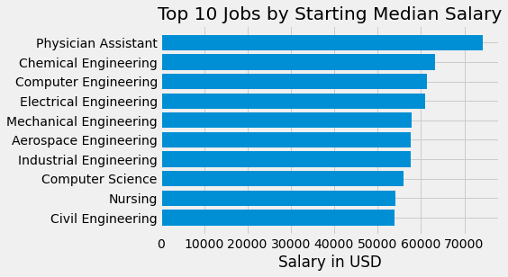

```python
plt.barh(undergrad_major_start, start_sal)
plt.title('Top 10 Jobs by Starting Median Salary')
plt.xlabel('Salary in USD')
plt.show()
```

Next, we will find the highest paying career at mid-career

```python
high_major_mid_sal = degrees_df.loc[degrees_df["Mid-Career Median Salary"].idxmax()]
```

```python
high_major_mid_sal
```

```
Undergraduate Major                                  Chemical Engineering
Starting Median Salary                                            63200.0
Mid-Career Median Salary                                         107000.0
Percent change from Starting to Mid-Career Salary                    69.3
Mid-Career 10th Percentile Salary                                 71900.0
Mid-Career 25th Percentile Salary                                 87300.0
Mid-Career 75th Percentile Salary                                143000.0
Mid-Career 90th Percentile Salary                                194000.0
Name: 8, dtype: object
```

```python
degrees_sorted_mid = degrees_df.sort_values('Mid-Career Median Salary', ascending=False)
```

```python
mid_sal = degrees_sorted_mid['Mid-Career Median Salary'].head(10)
```

```python
mid_sal
```

```
8     107000.0
12    105000.0
19    103000.0
1     101000.0
17     98600.0
44     97300.0
13     95500.0
30     94700.0
38     93600.0
37     92400.0
Name: Mid-Career Median Salary, dtype: float64
```

```python
mid_sal = mid_sal.iloc[::-1]
```

```python
undergrad_major_mid = degrees_sorted_mid['Undergraduate Major'].head(10)
```

```python
undergrad_major_mid = undergrad_major_mid.iloc[::-1]
```

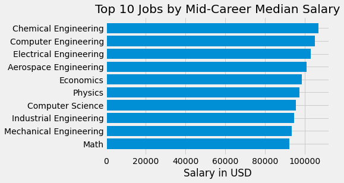

```python
plt.barh(undergrad_major_mid, mid_sal)
plt.title('Top 10 Jobs by Mid-Career Median Salary')
plt.xlabel('Salary in USD')
plt.show()
```

### Analyzing Salaries by College Type

Now, we will find the which college type offers the highest starting median salary. In order to that, we will need to group all colleges of the similar type together and take the mean.

```python
college_type = college_type_df["School Type"].unique()
```

```python
college_type = ['Ivy Leauge', 'Engineering', 'Liberal Arts', 'Party', 'State']
```

```python
college_type_start_mean = college_type_df.groupby("School Type")["Starting Median Salary"].mean()
```

```python
college_type_start_mean
```

```
School Type
Engineering     59057.894737
Ivy League      60475.000000
Liberal Arts    45746.808511
Party           45715.000000
State           44126.285714
Name: Starting Median Salary, dtype: float64
```

```python
college_type_start_plot = college_type_start_mean.sort_values().iloc[::-1]
```

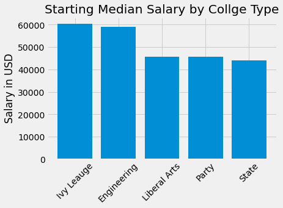

```python
plt.bar(college_type, college_type_start_plot)
plt.title("Starting Median Salary by Collge Type")
plt.ylabel("Salary in USD")
plt.xticks(rotation=45)
plt.show()
```

Next, we will find the highest mid-career salary by college type

```python
college_type_mid_mean = college_type_df.groupby("School Type")["Mid-Career Median Salary"].mean()
```

```python
college_type_mid_mean
```

```
School Type
Engineering     103842.105263
Ivy League      120125.000000
Liberal Arts     89378.723404
Party            84685.000000
State            78567.428571
Name: Mid-Career Median Salary, dtype: float64
```

```python
college_type_mid_mean = college_type_mid_mean.sort_values().iloc[::-1]
```

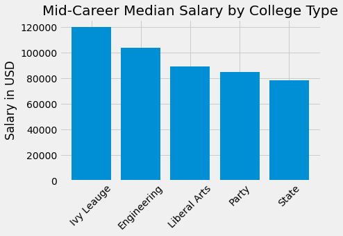

```python
plt.bar(college_type, college_type_mid_mean)
plt.title("Mid-Career Median Salary by College Type")
plt.ylabel("Salary in USD")
plt.xticks(rotation=45)
plt.show()
```

### Analyzing Salaries by College Region

In order to get a clear image on salaries by region, we need to group colleges by the region they are present in and then find mean. First, we will find the mean starting median salary by college region

```python
regions = region_df['Region'].unique()
```

```python
regions = ['California', 'Northeastern', 'Southern', 'Western', 'Midwestern' ]
```

```python
region_start_mean = (region_df.groupby("Region")["Starting Median Salary"].mean()).sort_values().iloc[::-1]
```

```python
region_start_mean
```

```
Region
California      51032.142857
Northeastern    48496.000000
Southern        44521.518987
Western         44414.285714
Midwestern      44225.352113
Name: Starting Median Salary, dtype: float64
```

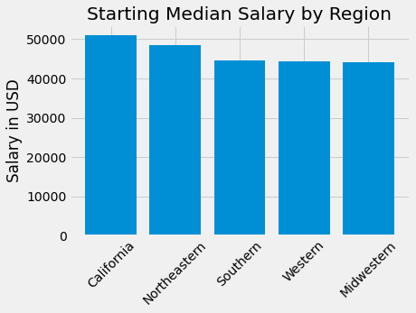

```python
plt.bar(regions, region_start_mean)
plt.title("Starting Median Salary by Region")
plt.ylabel("Salary in USD")
plt.xticks(rotation=45)
plt.show()
```

Now to find the mean mid-career salaries by region

```python
region_mid_mean = region_df.groupby("Region")["Mid-Career Median Salary"].mean().sort_values().iloc[::-1]
```

```python
region_mid_mean
```

```
Region
California      93132.142857
Northeastern    91352.000000
Southern        79505.063291
Western         78200.000000
Midwestern      78180.281690
Name: Mid-Career Median Salary, dtype: float64
```

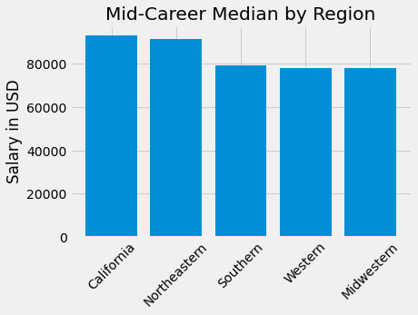

```python
plt.bar(regions, region_mid_mean)
plt.title("Mid-Career Median by Region")
plt.ylabel("Salary in USD")
plt.xticks(rotation=45)
plt.show()
```

## Conclusion

From the analysis of the data, it is evident Physician's Assistant offer the highest starting median salary. For individuals looking to earn more money immediately after graduation, it is recommended they pursue an Undergraduate Major to become Physician Assistant. If they are looking long term, then Chemical Engineering offers the highest median mid-career salary. If an individual is using College Type as the deciding factor, Ivy League schools offer both the highest starting median salaries and mid-career median salaries. If the individual is looking for colleges by region, California regions offering the highest starting median salaries and mid-career median salaries.